# Cryptocurrency: Price and Marketvalue

Prayosha Dhimmer

2023-03-02

## Cryptocurrency: Price and Makret

### What is Crytpcurrency?

**Crytpocurrency** is a type of currency which doesn’t rely on bank to verify transactions, instead its a peer-to-peer system that allows us to send and receive payments from anyone to anywhere. It runs on a blockchain, which is a record of all transactions updated and held by the currency holders.

### Purpose

**Goal** : To find correlations between cyrptocurrency market capitalization, prices and 24hr volumes to indentify potential investment opportunities. Lets understand the terms in brief:

- Market Capitalization: It shows how big or valuable a coin is, thus to decide if its worth buying. This is done via comparing the current value of the coin and all other available units combined based on supply and demand forces at work in CryptoCurrency eco system.
- Prices: Price of each coin trading at any given time.
- 24h volume: Volume of the coin traded in last 24h. This helps users to understand the momentum of the market vis-a-vis volume traded during that period for cryptocurrency trading and understanding liquidity situation in any given period.

**Key Factors**: The worth of the coin and future of most and least worthy coin.

### Preparation Phase

Data Source: Gimenez Morales, Albert. (2022). Coin gecko scraper example [Data set]. Zenodo. [Click Here](https://doi.org/10.5281/zenodo.6366514)

License: Creative Common Attribution 4.0 International.

All of the dataset was verified: It’s unbiased and credible.

### Process Phase

It is important to go through your data once to encounter any errors before beginning to analyze your data. The dataset was cleaned using Excel. It included steps like: deleting the records with some null values in it as this might create hindrance to our analysis process, making sure all the values are unique and no misspelled values.Also, the datatype for each column and the proper date format.

### Analyze Phase

As the dataset has too many number of rows, switching to BigQuery for analysis was best.

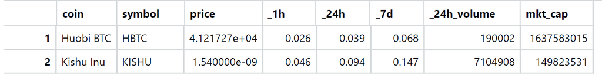

Comparison between 2 coins

Let’s understand the dataset:

- The coin and symbol: are the coin names and its abbreviation respectively.
- The columns marked X proceeding are the time periods: 1hr, 24hr, 7days and 24hr volume.
- mkt_cap simply stands for Market Capitalization.

The correlation between Cryptocurrency market capitalization and prices based on 24hr volume:

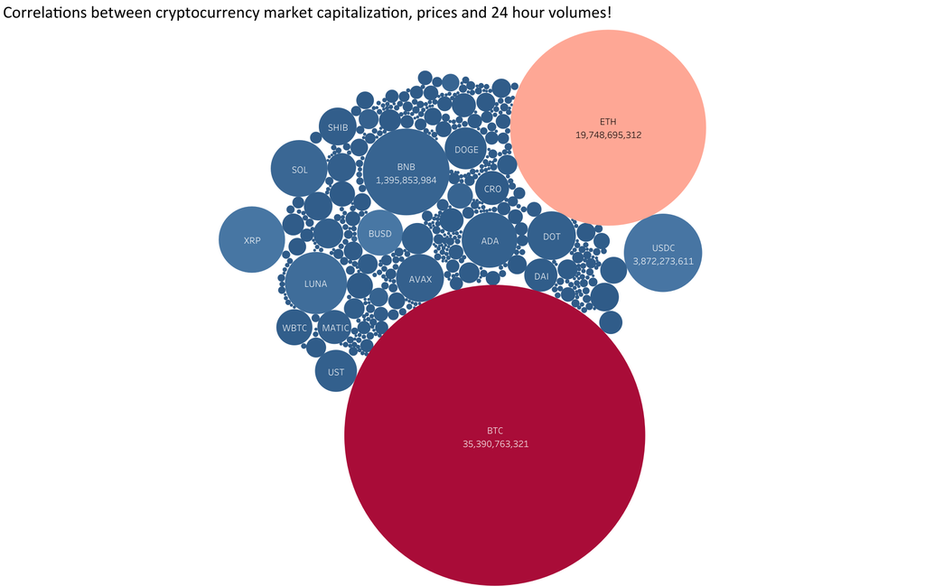

### Credits

Gimenez Morales, Albert. (2022). Coin gecko scraper example [Data set]. Zenodo. https://doi.org/10.5281/zenodo.6366514